# Assignment #0 - R Basics

Jinwen Wu

1. Load the freeny dataset as fdata
2. To see what is in the data, use the View(fdata) command.

```r
fdata <- freeny
View(fdata)
```

3. Check what variables are in your dataset using the names(fdata) command. List the names of the last two variables in the dataset in the main text (not in a code or output chunk)

```r
names(fdata)
```

```
[1] "y"                     "lag.quarterly.revenue" "price.index"
[4] "income.level"          "market.potential"
```

Answer: The last two variable names are: “income.level” and “market.potential” .

4. Find the mean of the lag quarterly revenue using the summary(fdata) command. Report it in the main text of your notebook.

```r
summary(fdata)
```

```
       y         lag.quarterly.revenue  price.index     income.level
 Min.   :8.791   Min.   :8.791         Min.   :4.278   Min.   :5.821
 1st Qu.:9.045   1st Qu.:9.020         1st Qu.:4.392   1st Qu.:5.948
 Median :9.314   Median :9.284         Median :4.510   Median :6.061
 Mean   :9.306   Mean   :9.281         Mean   :4.496   Mean   :6.039
 3rd Qu.:9.591   3rd Qu.:9.561         3rd Qu.:4.605   3rd Qu.:6.139
 Max.   :9.794   Max.   :9.775         Max.   :4.710   Max.   :6.200
 market.potential
 Min.   :12.97
 1st Qu.:13.01
 Median :13.07
 Mean   :13.07
 3rd Qu.:13.12
 Max.   :13.17
```

Answer： The mean of the lag quarterly revenue is 9.281.

5. Find the standard deviation of the income level using the sd(fdata$income.level) command, which tells R to find the standard deviation (sd) of the column called income.level of the data object fdata.

```r
sd(fdata$income.level)
```

```
[1] 0.1204432
```

Answer：The standard deviation of the income level is 0.1204432.

6. Make a new variable that is the mean of the income level and the price index using the command fdata$newvarname <- (fdata$varname1 + fdata$varname2)/2

```r
fdata$newvarname <- (fdata$income.level + fdata$price.index)/2
```

Answer: A variable is created accordingly.

7. Run a linear regression where y is the dependent variable (a.k.a. y-variable) and the market potential and newvarname are the independent variables (a.k.a. x-variables or explanatory variables) using the command

```r
model1 <- lm(y ~ newvarname + market.potential, data=fdata)
summary(model1)
```

```
Call:
lm(formula = y ~ newvarname + market.potential, data = fdata)

Residuals:
      Min        1Q    Median        3Q       Max
-0.067997 -0.011645  0.003757  0.013909  0.039318

Coefficients:
                  Estimate Std. Error t value Pr(>|t|)
(Intercept)      -56.73132    1.71007 -33.175   <2e-16 ***
newvarname         0.34546    0.22095   1.564    0.127
market.potential   4.91458    0.06954  70.677   <2e-16 ***
---
Signif. codes:  0 ‘***’ 0.001 ‘**’ 0.01 ‘*’ 0.05 ‘.’ 0.1 ‘ ’ 1

Residual standard error: 0.02588 on 36 degrees of freedom
Multiple R-squared:  0.9936,    Adjusted R-squared:  0.9933
F-statistic:  2808 on 2 and 36 DF,  p-value: < 2.2e-16
```

8. The regression should show output in your console and in your .Rmd file that will look something like this (using a different set of variables so as not to give away the answer):

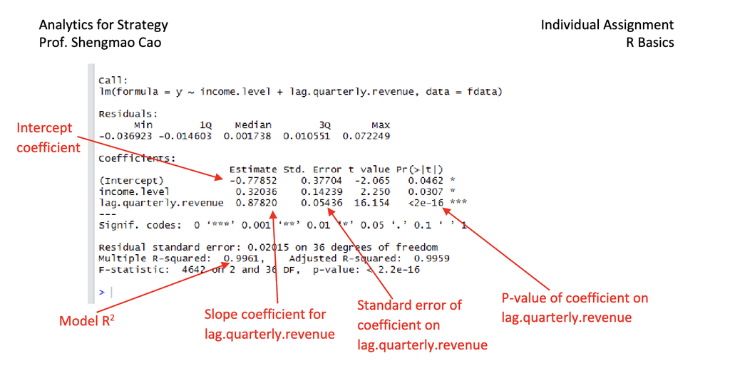

9. Report in your notebook the value of the intercept coefficient and the slope coefficient on market potential. Interpret the coefficient on market potential: based on this regression, for every 1-unit increase in market potential, by how many units would we expect y to rise or fall?

Answer:

9.1: The intercept coefficient is -56.73132. This value represents the expected value of the dependent variable y when both independent variables(newvarname and market.potential) are held at zero.

9.2: The slope coefficient for market.potential is approximately 4.91458. This coefficient indicates that for every one-unit increase in market.potential, the dependent variable y is expected to increase by approximately 4.91458 units, assuming all other variables in the model are held constant.

10. Save your .Rmd notebook and submit it through Canvas. Also submit the HTML file generated by the notebook.

```r
# structure
str(fdata)
```

```
'data.frame':   39 obs. of  6 variables:
 $ y                    : Time-Series  from 1962 to 1972: 8.79 8.79 8.81 8.81 8.91 ...
 $ lag.quarterly.revenue: num  8.8 8.79 8.79 8.81 8.81 ...
 $ price.index          : num  4.71 4.7 4.69 4.69 4.64 ...
 $ income.level         : num  5.82 5.83 5.83 5.84 5.85 ...
 $ market.potential     : num  13 13 13 13 13 ...
 $ newvarname           : num  5.27 5.26 5.26 5.26 5.25 ...
```

Regress y on price index R^2: how well the linear model fits the data； this is more about prediction than causation. Pr is the P value mod_ex <- lm( y ~ price.index, data = fdata )

```r
mod_ex <- lm(
y ~ price.index, data = fdata
)
summary(mod_ex)
```

```
Call:
lm(formula = y ~ price.index, data = fdata)

Residuals:
     Min       1Q   Median       3Q      Max
-0.06666 -0.03696 -0.01259  0.03773  0.08382

Coefficients:
            Estimate Std. Error t value Pr(>|t|)
(Intercept)  19.8359     0.2528   78.46   <2e-16 ***
price.index  -2.3419     0.0562  -41.67   <2e-16 ***
---
Signif. codes:  0 ‘***’ 0.001 ‘**’ 0.01 ‘*’ 0.05 ‘.’ 0.1 ‘ ’ 1

Residual standard error: 0.0462 on 37 degrees of freedom
Multiple R-squared:  0.9791,    Adjusted R-squared:  0.9786
F-statistic:  1736 on 1 and 37 DF,  p-value: < 2.2e-16
```

Economic significance ： the magnitutde of the coefficient

grade_data$freshman <- as.integer(grade_data$cohort == “Freshman”) Create a dummy called “freshman” that is 1 if cohort is “Freshman”; otherwise, freshman == 0.